# Final Project: Lynching in the US from 1883-1941, final results

Freja Skall Thorøe

10/01/2022

# Introduction to the script

The following script is both showing my final results as well as thoughts I did while working. The first few headlines are graphs of the data. Later in the script all my attemps at mapping the lynchings will be shown. To make sure that my code can be made into an html document, I marked my failed codes with an “#”.

# The used datasets and visualizing the data

Loading the library and document with the lynching data from David Rigby and Charles Sequin’s study, “National Crimes: A New National Data Set of Lynchings in the United States, 1883 to 1941.”

This first upload is the raw version directly from Seguins online Archive.

```r
library(tidyverse)
library(dplyr)
library(usmap)
```

```r
library(ggplot2)
library(leaflet)
library(sp)
library(maps)
Lynching_data_Rigby_raw <- read_csv('/Users/freja/AU - R/Final_Project/Datasets for assignment/Seguin_data_lynchingUS_raw.csv')
head(Lynching_data_Rigby_raw)
```

```
## # A tibble: 6 x 18
##   caseid   year month   day full_fips state state_fips county county_fips city
##   <chr>   <dbl> <dbl> <dbl> <chr>     <chr> <chr>      <chr>  <chr>       <chr>
## 1 6931     1890     4    22 5091      AR    5          MILLER 91          Camer~
## 2 Pfiefe~  1883     9     3 4021      AZ    4          PINAL  21          Flore~
## 3 Pfiefe~  1883     9     3 4021      AZ    4          PINAL  21          Flore~
## 4 Pfiefe~  1883    12     1 4021      AZ    4          PINAL  21          Cooli~
## 5 Pfiefe~  1884     2    22 4003      AZ    4          COCHI~ 3           Tombs~
## 6 Pfiefe~  1884     8    30 4021      AZ    4          PINAL  21          Pinal
## # ... with 8 more variables: victim <chr>, gender <chr>, race <chr>,
## #   alleged_offense <chr>, lynch_method <chr>, composition_of_mob <chr>,
## #   source_of_record <chr>, confirming_document <chr>
```

The dataset looks alright upfront, however, it’s got a few black cells and some cells with only “.” in them. I will use OpenRefine to correct so all cells are filled out. I also correct the county cell, so that it didn’t have uppercase letters except for the first letter. This new dataset will be in the github repository: ‘https://github.com/Digital-Methods-HASS/AU677820-Thoroe-Freja’, under the name “Seguin_data_lynchings_tidy.csv”

```r
Lynching_data_Rigby_tidy <- read_csv('/Users/freja/AU - R/Final_Project/Datasets for assignment/Seguin_data_lynchingUS_tidy.csv')
head(Lynching_data_Rigby_tidy)
```

```
## # A tibble: 6 x 18
##   case_id   year month   day full_fips state state_fips county county_fips city
##   <chr>    <dbl> <dbl> <dbl> <chr>     <chr>      <dbl> <chr>        <dbl> <chr>
## 1 6931      1890     4    22 05091     AR             5 miller          91 Came~
## 2 Pfiefer~  1883     9     3 04021     AZ             4 pinal           21 Flor~
## 3 Pfiefer~  1883     9     3 04021     AZ             4 pinal           21 Flor~
## 4 Pfiefer~  1883    12     1 04021     AZ             4 pinal           21 Cool~
## 5 Pfiefer~  1884     2    22 04003     AZ             4 cochi~           3 Tomb~
## 6 Pfiefer~  1884     8    30 04021     AZ             4 pinal           21 Pinal
## # ... with 8 more variables: victim <chr>, gender <chr>, race <chr>,
## #   alleged_offense <chr>, lynch_method <chr>, composition_of_mob <chr>,
## #   source_of_record <chr>, confirming_document <chr>
```

Now I want to look into the data a little more. First I wanna look at the development in the amounts of lynchings in the period from 1883 to 1941. But first I’ll have to make another table that contains the amounts of lynchings pr. year.

## Lynchings pr. year

```r
Lynchings_pr_year <- Lynching_data_Rigby_tidy %>%
  group_by(year) %>%
  count(year,sort = TRUE)

Lynchings_pr_year <- rename(Lynchings_pr_year, number_of_lynchings=n)

head(Lynchings_pr_year)
```

```
## # A tibble: 6 x 2
## # Groups:   year [6]
##    year number_of_lynchings
##   <dbl>               <int>
## 1  1884                  90
## 2  1883                  74
## 3  1885                  72
## 4  1886                  69
## 5  1895                  63
## 6  1892                  60
```

Now I can plot this new data into ggplot and make graphs.

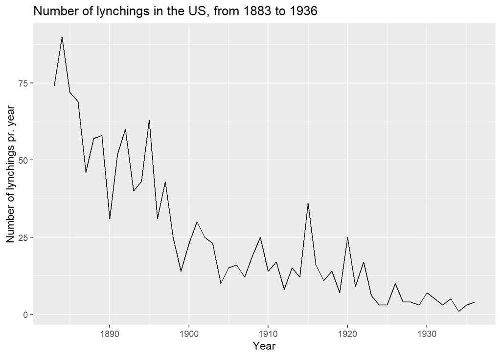

```r
Lynchings_pr_year %>%
  ggplot()+
  geom_line(mapping = aes(x=Lynchings_pr_year$year,
                          y=number_of_lynchings))+
  labs(x="Year",
       y="Number of lynchings pr. year",
       title = "Number of lynchings in the US, from 1883 to 1936")
```

Geom_smooth is more easy on the eyes. But choosing the geom_line since it shows the patterns better. The graph clearly shows hos the number of lynchings decreased from 1883-1936. The amounts of lynchings seems to be lower than other dataset. I will try to load another dataset that show lynchings.

## Tuskegee Institute data

```r
Lynching_data_Tuskegee <- read_csv('/Users/freja/AU - R/Final_Project/Datasets for assignment/LynchingUS_Tuskegee_data_tidy.csv')
```

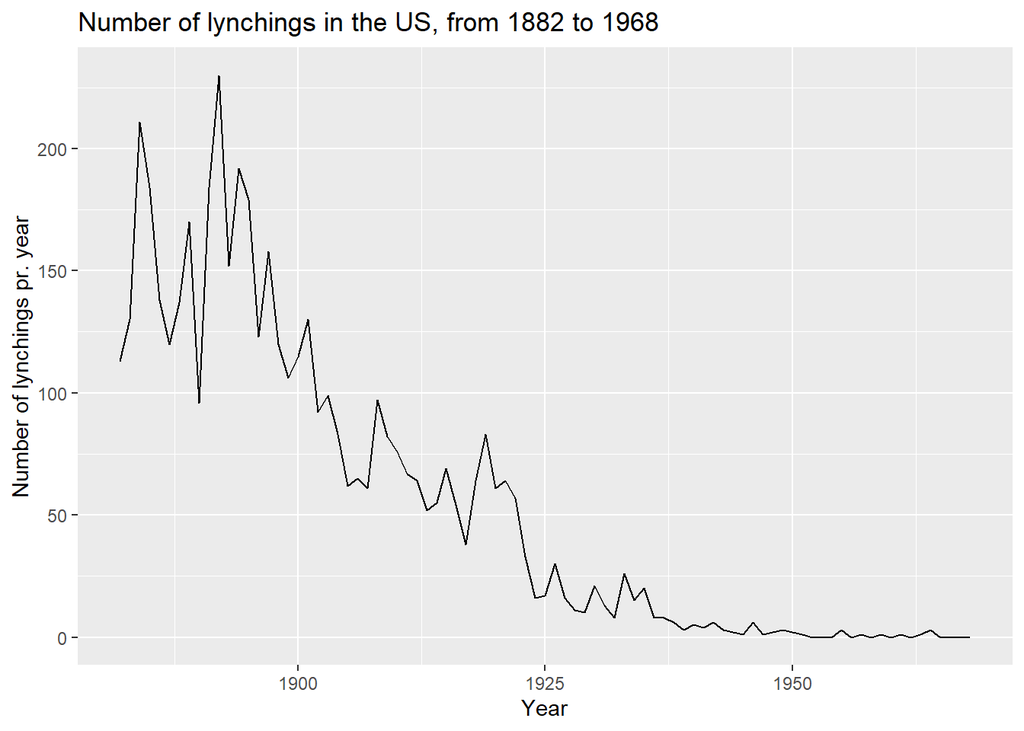

```r
Lynching_data_Tuskegee %>%
  ggplot()+
  geom_line(mapping = aes(x=Lynching_data_Tuskegee$Year,
                          y=Lynching_data_Tuskegee$Total))+
  labs(x="Year",
       y="Number of lynchings pr. year",
       title = "Number of lynchings in the US, from 1882 to 1968")
```

The graph from the Tuskegee Institute data has a very similar pattern to the Rigby data.

The Rigby data also has a lot of other variables that could be interesting to look at. First I will take a look on how many lynchings that were done from state to state.

```r
Lynchings_pr_state <- Lynching_data_Rigby_tidy %>%
  drop_na(state) %>%
  group_by(state) %>%
  count(state,sort = TRUE)
Lynchings_pr_state <- rename(Lynchings_pr_state,number_of_lynchings_pr_state=n)
head(Lynchings_pr_state)
```

```
## # A tibble: 6 x 2
## # Groups:   state [6]
##   state number_of_lynchings_pr_state
##   <chr>                        <int>
## 1 TX                             438
## 2 OK                             105
## 3 MO                             101
## 4 VA                              90
## 5 MT                              67
## 6 KS                              50
```

Texas is the state with most lynching incidents. It would still be interesting to see if the lynched victims were mostly black. I use the same technique to count the lynchings pr. race.

```r
Lynchings_pr_race <- Lynching_data_Rigby_tidy %>%
  group_by(race) %>%
  drop_na(race) %>%
  count(race, sort = TRUE)
Lynchings_pr_race <- rename(Lynchings_pr_race,number_of_lynchings_pr_race=n)
head(Lynchings_pr_race)
```

```
## # A tibble: 6 x 2
## # Groups:   race [6]
##   race            number_of_lynchings_pr_race
##   <chr>                                 <int>
## 1 Black                                   621
## 2 White (?)                               402
## 3 White                                   192
## 4 Mexican                                  71
## 5 American Indian                          32
## 6 Chinese                                   9
```

Both the graph of the Rigby data and the Tuskegee data show the US total number lynchings. And they don’t show what the race the victims had. However, it could be interesting to see how many victims were black and white, and if there was a development of that over time.

# Making visualizations with ggplot

## Lychings pr. year and race

After a few tries entering the whole Rigby dataset into R, and only getting mushed and incomprehensible outputs, I decided once more to only make a graph with a few observations from the dataset, such as, year, race, and total number of lynchings.

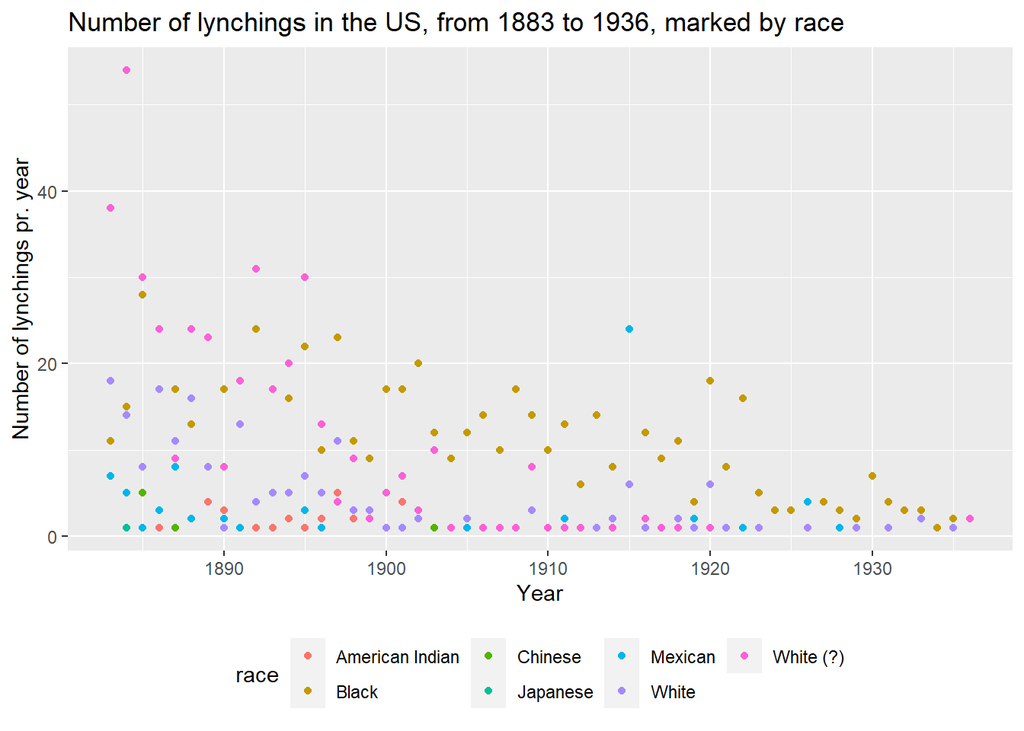

```r
Lynchings_by_year_race <- Lynching_data_Rigby_tidy %>%
  group_by(year) %>%
  count(race, sort = TRUE)

Lynchings_by_year_race <- rename(Lynchings_by_year_race,number_of_victims=n)

Lynchings_by_year_race %>%
  ggplot()+
  geom_point(mapping = aes(x=Lynchings_by_year_race$year,
                          y=Lynchings_by_year_race$number_of_victims,
                          color = race))+
  theme(legend.position = "bottom")+
  labs(x = "Year",
       y="Number of lynchings pr. year",
       title = "Number of lynchings in the US, from 1883 to 1936, marked by race")
```

This visualization was quite succesfull. It shows the development of lynchings pr. year and sorts it by race. That way it becomes clear, that most of the lynchings in the late 19th century were white, or maybe white. It matches with the different regimes that David Rigby is making in his article “National Crimes: A New National Data Set of Lynchings in the United States, 1883 to 1941.” Where he points to 3 different regimes: A Wild West Regime, where mostly whites were lynched in areas with weak state penetration; a slavey regime, found in former slave states, mostly in the south; and a minor regime of Mexican nationals being lynched along the Texas-Mexico border.

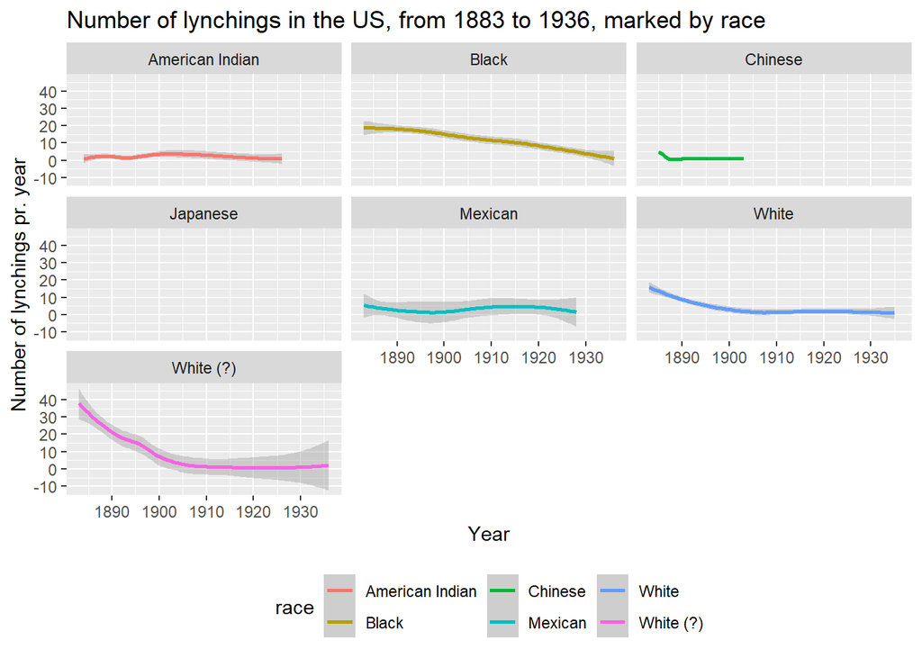

```r
ggplot(data = Lynchings_by_year_race)+
  geom_smooth(mapping = aes(x=Lynchings_by_year_race$year,
                          y=Lynchings_by_year_race$number_of_victims,
                          color = race))+
  facet_wrap(~race, nrow = 4,ncol = 3)+
  theme(legend.position = "bottom")+
  labs(x = "Year",
       y="Number of lynchings pr. year",
       title = "Number of lynchings in the US, from 1883 to 1936, marked by race")
```

Here it becomes clear, that the development in the lynching of whites (both White and White ? - meaning white, european immigrants) is declining fast after 1890. For Black it only declines slowly, and the numbers are quite high even in the beginning of the 1900s.

## Lychings pr. year and state

Using the same technique to see which states had the most lynchings and if it was mostly southern states.

```r
Lynchings_by_year_state <- Lynching_data_Rigby_tidy %>%
  group_by(year) %>%
  count(state, sort = TRUE)
Lynchings_by_year_state <- rename(Lynchings_by_year_state, number_of_lynchings=n)
(Lynchings_by_year_state)
```

```
## # A tibble: 429 x 3
## # Groups:   year [54]
##     year state number_of_lynchings
##    <dbl> <chr>               <int>
##  1  1915 TX                     31
##  2  1884 MT                     28
##  3  1895 TX                     23
##  4  1886 TX                     22
##  5  1885 TX                     21
##  6  1897 TX                     20
##  7  1883 TX                     19
##  8  1887 TX                     16
##  9  1922 TX                     16
## 10  1884 TX                     15
## # ... with 419 more rows
```

Visualizing the new table:

[output not shown]

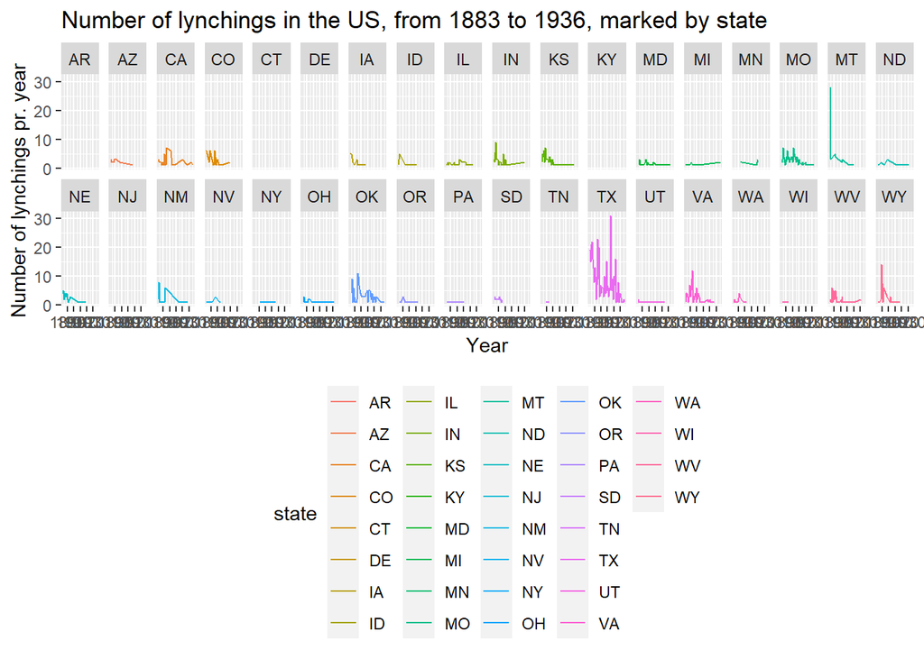

```r
ggplot(data = Lynchings_by_year_state)+
  geom_line(mapping = aes(x=Lynchings_by_year_state$year,
                          y=Lynchings_by_year_state$number_of_lynchings,
                          color = state))+
  facet_wrap(~ state, nrow =18,ncol =18 ) +
  theme(legend.position = "bottom")+
  labs(x = "Year",
       y="Number of lynchings pr. year",
       title = "Number of lynchings in the US, from 1883 to 1936, marked by state")
```

This way of looking at the lynchings in the states is quite messy and not very comprehensible. Using maps would be way better.

# Mapping the lynching: In which part of the US was it occuring most frequently?

## Making maps with ggplot2

First I try to find a way to make a US map.

When I change the data from state -> county, it does not work, since it still shows the US states.

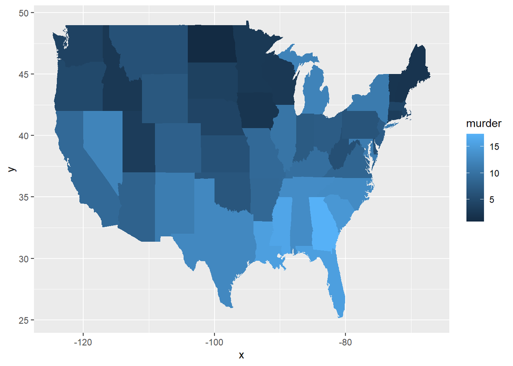

```r
ggplot_data <- data.frame(murder = USArrests$Murder, county = tolower(rownames(USArrests)))
map <- map_data("county")
k <- ggplot(ggplot_data,aes(fill= murder))
k+geom_map(aes(map_id=county), map=map)+
  expand_limits(x=map$long, y=map$lat)
```

However, when entering my own data, it did not seem to work. There was a fault in aesthetics. That I couldn’t figure out how to solve.

## Making maps with the USmap package

First installing the right packages and activation the libraries.

I tried following this guide: https://jtr13.github.io/cc19/different-ways-of-plotting-u-s-map-in-r.html.

I found out that the “USmap” package already had made up maps, however, I do not know how to add markers automatically. I can add markers manually, but it would take me forever with the large dataset I am working with.

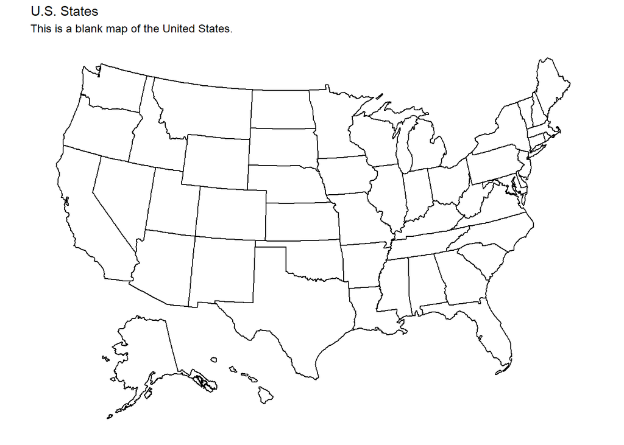

```r
plot_usmap(regions = "states") +
  labs(title = "U.S. States",
       subtitle = "This is a blank map of the United States.") +
  theme(panel.background=element_blank())
```

Trying to create map from dataset in the guide.

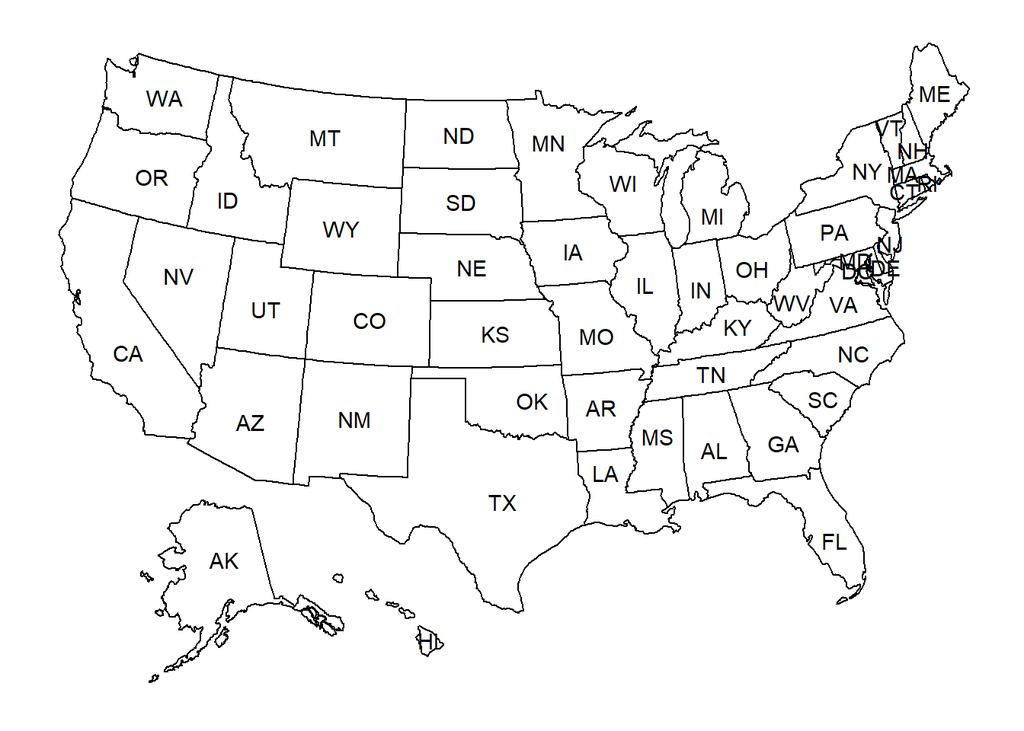

```r
usmap::plot_usmap("states", labels = TRUE)
```

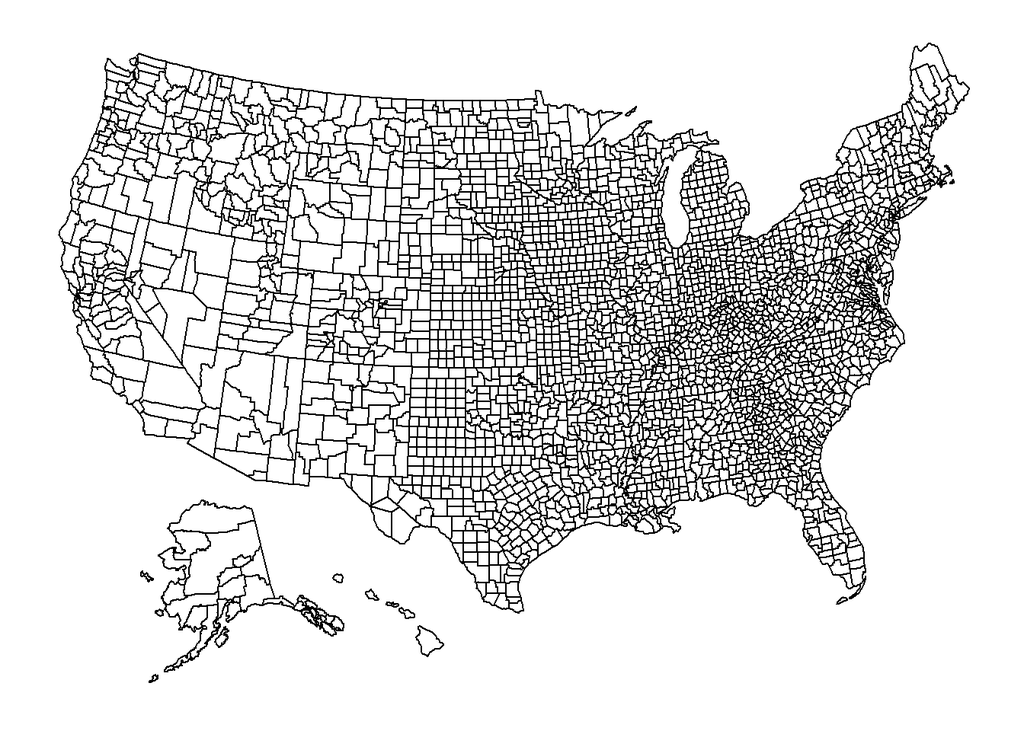

```r
usmap::plot_usmap("counties", labels = FALSE)
```

With the USmap package it is possible to join the package with another dataset. This dataset can only contain 2 columns, on that contains the fibs (for state, or county) and one that contains the values. So first, I will have to make a new table, that can be used. I followed this discription of the USmap package: ‘https://cran.r-project.org/web/packages/usmap/usmap.pdf’

```r
Lynchings_sorted_by_county <- Lynching_data_Rigby_tidy %>%
  select(full_fips,victim)
```

Now that we have a table with two columns, we can test it with the USmap package. I still get fault messages. It seems that I can only add one column to the USmap which is making the tool limited. So I have to use another method. I use the “#” to mark when I have tried a function that does not work.

```r
#Lynchings_sorted_by_county %>%
#map_with_data(full_fips,values = "victim",include = c(), exclude = c(),na=NA)
```

I get the: Error in map_with_data(., full_fips, values = “victim”, include = c(), : unused argument (full_fips).

I cannot seem to get the data to work together, so I will try another solution.

## Second attempt in mapping with ggplot:

Trying to follow a YouTube Guide on how to make maps: “https://www.youtube.com/watch?v=AgWgPSZ7Gp0”

Making sure to read the necessary libraries and then I load the “map_data” set with latitude and longtitude for all countries and regions.

```r
#Loading data:
mapdata <- map_data("county")
mapdata <-rename(mapdata, county=subregion)
```

Renaming the “subregion” column in mapdata to “county” to be able to join or merge.

```r
#mapdata_Lynching <- #anti_join(mapdata,Lynching_data_Rigby_tidy, by = "county")
```

It keeps showing the faultmessage: “Error: Join columns must be present in data. x Problem with `county`. Run `rlang::last_error()` to see where the error occurred.” And I cant figure out why the two datasets will not be joined either by: full_join, anti_join, righ_join, left_join or the merge function.

Since I could not get the county to merge or join, I wanted to try and see wheather the FIPS codes could be joined.

I found a dataset that said it had both coordinates and FIPS, so I loaded it into R, however, it didn’t contain latitude and longtitude. So I again had to find another way of getting my data ready for mapping.

```r
#US_fips_lng_lat <- read_csv("/Users/freja/AU - R/Final_Project/Datasets for assignment/ZIP-COUNTY-FIPS_2010-03.csv")

#renaming the "STCOUNTYFP" to "full_fips".
#US_fips_lng_lat <- rename(US_fips_lng_lat,full_fips=STCOUNTYFP)
#(US_fips_lng_lat)
```

# Attempting to map with Leaflet in R.

Following Brent Thorne, “Leaflet MApping in RStudio - Adding Markers”: https://www.youtube.com/watch?v=dBk8gGX1MNk

## Making a map over the lynchings pr. state

```r
US_states_lat_lng <- read.csv('/Users/freja/AU - R/Final_Project/df_us_states_coordinates/world_country_and_usa_states_latitude_and_longitude_values.csv')
US_states_lat_lng$country_code=NULL
US_states_lat_lng$latitude=NULL
US_states_lat_lng$longitude=NULL
US_states_lat_lng$country=NULL
US_states_lat_lng <- rename(US_states_lat_lng, state=usa_state_code)
head(US_states_lat_lng)
```

```
##   state usa_state_latitude usa_state_longitude  usa_state
## 1    AK           63.58875          -154.49306     Alaska
## 2    AL           32.31823           -86.90230    Alabama
## 3    AR           35.20105           -91.83183   Arkansas
## 4    AZ           34.04893          -111.09373    Arizona
## 5    CA           36.77826          -119.41793 California
## 6    CO           39.55005          -105.78207   Colorado
```

Now I will be ready to merge the two tables…

```r
Lynching_states_merge <- merge(Lynching_data_Rigby_tidy,US_states_lat_lng, by = "state", )
head(Lynching_states_merge)
```

```
##   state       case_id year month day full_fips state_fips  county county_fips
## 1    AR          6931 1890     4  22     05091          5  miller          91
## 2    AZ  Pfiefer_AZ_8 1883     9   3     04021          4   pinal          21
## 3    AZ  Pfiefer_AZ_9 1883     9   3     04021          4   pinal          21
## 4    AZ Pfiefer_AZ_11 1883    12   1     04021          4   pinal          21
## 5    AZ Pfiefer_AZ_12 1884     2  22     04003          4 cochise           3
## 6    AZ Pfiefer_AZ_13 1884     8  30     04021          4   pinal          21
##              city           victim gender  race
## 1 Cameron Station          Unknown   Male Black
## 2        Florence     Len Redfield   Male White
## 3        Florence       Joe Tuttle   Male White
## 4        Coolidge James J. Johnson   Male White
## 5       Tombstone       John Heith   Male White
## 6           Pinal            Fales   Male White
##                                              alleged_offense lynch_method
```

[output cut: 27 more lines]

Now I finally have a map with coordinates in it so I can make markers in leaflet or use ggplot2. Depending on what method suits better. But first I try with leaflet.

## Mapping the number of lynchings pr. state. Using leaflet

First I will clean my data titles, so that I will able to use the table in an easy way:

```r
Lynching_states_merge <- rename(Lynching_states_merge, latitude=usa_state_latitude)
Lynching_states_merge <- rename(Lynching_states_merge, longitude=usa_state_longitude)
```

Preparing the data for mapping: first, making sure that my lng, lat are numerics.

```r
Lynching_states_merge$longitude <- as.numeric(Lynching_states_merge$longitude)
Lynching_states_merge$latitude <- as.numeric(Lynching_states_merge$latitude)
```

Creating a new spacialpoints dataframe. Not sure why I did this step.

```r
Lynching_states_merge_SP <- SpatialPointsDataFrame(Lynching_states_merge[,c(19,20)],Lynching_states_merge[,-c(19,20)])
```

Now I can place my markers.

```r
map_lynchings_pr_state <- leaflet() %>%
  setView(-93.65,42.0285,zoom = 4) %>%
  addTiles() %>%
  addMarkers(data = Lynching_states_merge, lng = ~longitude,lat = ~latitude,popup = ~victim)

map_lynchings_pr_state
```

[interactive chart not shown]

It seems that only one marker is placed for each state, so that the rest who were lynched in the same state aren’t shown.

Trying to add circles instead, to see if that makes a difference.

```r
Lynching_pr_state_map <- leaflet() %>% setView(-93.65, 42.0285, zoom = 4) %>%
  addTiles() %>%
  addCircles(data = Lynching_states_merge, lng = ~longitude,lat = ~latitude, weight = 30,
    radius = ~sqrt(1), popup = ~victim)

Lynching_pr_state_map
```

[interactive chart not shown]

Did not really work either…

## Forth attempt at using ggplot and the maps package:

I tried following Mike Gruszczynski’s guide on mapping in R using ggplot. Most of the code is taken direcly from Gruszczynski’s example.

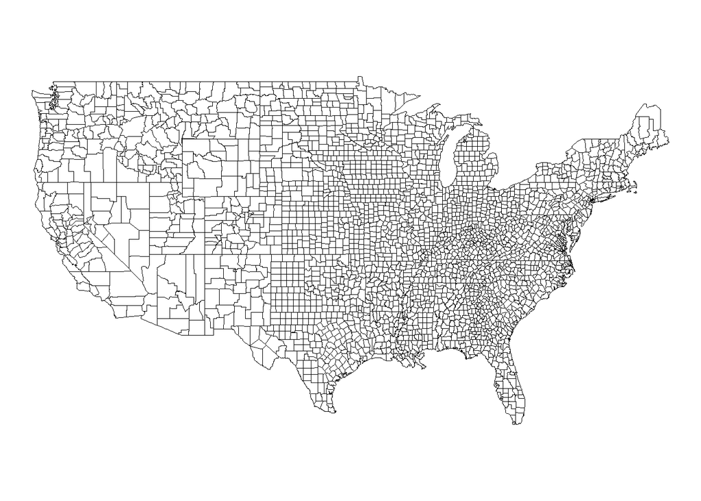

```r
counties <- map_data("county")
ggplot(data=counties) +
  geom_polygon(aes(x=long, y=lat, group=group), colour="black", fill='white', size=.2) +
  coord_fixed(1.3) + theme_void()
```

Now I try to load the fips codes. I call them fips_codes. Since the county.fips region and subregion data are merged inder “polynam”, I first will have to separate these.

```r
fips_codes <- county.fips %>%
   separate(polyname, c("region", "subregion"), ",")
head(fips_codes)
```

```
##   fips  region subregion
## 1 1001 alabama   autauga
## 2 1003 alabama   baldwin
## 3 1005 alabama   barbour
## 4 1007 alabama      bibb
## 5 1009 alabama    blount
## 6 1011 alabama   bullock
```

Now it’s time to merge the fips_codes data with the counties data. First I use the anti_join function to make sure that there is no troublesome cells in the merging of the columns. The anti_join function keeps only those observations in the counties dataset that don’t match with the ones in the fips_codes dataset.

```r
anti_join(counties, fips_codes, by=c("region","subregion")) %>%
  select(region,subregion) %>%
  group_by(region,subregion) %>%
  summarise(n())
```

```
## # A tibble: 8 x 3
## # Groups:   region [7]
##   region         subregion     `n()`
##   <chr>          <chr>         <int>
## 1 florida        okaloosa         37
## 2 louisiana      st martin        85
## 3 north carolina currituck        97
## 4 south dakota   oglala dakota    23
## 5 texas          galveston        62
## 6 virginia       accomack         83
## 7 washington     pierce           87
## 8 washington     san juan         53
```

There are 8 problem counties that don’t match up. To see what these are called in the fips_codes dataset I filter the troublesome cells

```r
fips_codes %>%
  filter(grepl("okaloo|martin|curri|oglala|galve|acco|pierc|juan", subregion))
```

```
##     fips         region                subregion
## 1   8111       colorado                 san juan
## 2  12085        florida                   martin
## 3  12091        florida            okaloosa:main
## 4  12091        florida            okaloosa:spit
## 5  13229        georgia                   pierce
## 6  18101        indiana                   martin
## 7  21159       kentucky                   martin
## 8  22099      louisiana          st martin:north
## 9  22099      louisiana          st martin:south
## 10 27091      minnesota                   martin
## 11 31139       nebraska                   pierce
## 12 35045     new mexico                 san juan
## 13 37053 north carolina         currituck:knotts
## 14 37053 north carolina           currituck:main
## 15 37053 north carolina           currituck:spit
## 16 37117 north carolina                   martin
## 17 38069   north dakota                   pierce
## 18 48167          texas           galveston:main
## 19 48167          texas           galveston:spit
## 20 48317          texas                   martin
## 21 49037           utah                 san juan
## 22 51001       virginia            accomack:main
## 23 51001       virginia    accomack:chincoteague
## 24 53053     washington              pierce:main
## 25 53053     washington           pierce:penrose
## 26 53055     washington    san juan:lopez island
## 27 53055     washington    san juan:orcas island
## 28 53055     washington san juan:san juan island
## 29 55093      wisconsin                   pierce
```

When separating the commaseparated values earlier, a few colonseparated subsubregion splits. These I have to split again.

First i separate the region and subregion, and then I separate the subrigion and the sub-subregion.

```r
fips_codes <- county.fips %>%
  separate(polyname, c("region","subregion"), ",",) %>%
  separate(subregion, c("subregion","subsubregion"), ":")
```

```
## Warning: Expected 2 pieces. Missing pieces filled with `NA` in 3069 rows [1, 2,
## 3, 4, 5, 6, 7, 8, 9, 10, 11, 12, 13, 14, 15, 16, 17, 18, 19, 20, ...].
```

The warning-message is shown because of some missing values (NA), however the code still seems to work.

```r
anti_join(counties, fips_codes, by=c("region","subregion")) %>%
  select(region,subregion) %>%
  group_by(region,subregion) %>%
  summarise(n())
```

```
## # A tibble: 1 x 3
## # Groups:   region [1]
##   region       subregion     `n()`
##   <chr>        <chr>         <int>
## 1 south dakota oglala dakota    23
```

Since I have now checked the data with the anti_join function, I can now full_join the “counties” and the “fips_codes”.

```r
counties <- full_join(counties, fips_codes, by=c("region","subregion"))

counties <- rename(counties,county=subregion)
head(counties)
```

```
##        long      lat group order  region  county fips subsubregion
## 1 -86.50517 32.34920     1     1 alabama autauga 1001         <NA>
## 2 -86.53382 32.35493     1     2 alabama autauga 1001         <NA>
## 3 -86.54527 32.36639     1     3 alabama autauga 1001         <NA>
## 4 -86.55673 32.37785     1     4 alabama autauga 1001         <NA>
## 5 -86.57966 32.38357     1     5 alabama autauga 1001         <NA>
## 6 -86.59111 32.37785     1     6 alabama autauga 1001         <NA>
```

Now I have a table with both FIPS and longtitude and latitude. So I can try to join lynching data with this new dataset.

Now I try to join my tables together: First trying the following:

```r
#Lynching_counties_merge <- merge(Lynching_data_Rigby_tidy,counties, by = "county", )
#view(Lynching_counties_merge)
```

Does not work…I don’t understand why I get this faultmessage: “Error in fix.by(by.y, y) : ‘by’ skal angive en unik gyldig kolonne”, since I’ve checked that both “county” columns are “chr”

A stack user said to specify the by.x and by.y (https://stackoverflow.com/questions/33047218/merge-problems-in-r-error-in-fix-byby-x-x-by-must-specify-uniquely-valid/39695057)

```r
#Lynching_counties_merge <- merge(Lynching_data_Rigby_tidy, counties, by.x = c("county"), by.y = c("county"))
#head(Lynching_counties_merge)
```

I keep getting this faultmesseage: “Error in fix.by(by.x, x) : ‘by’ skal angive en unik gyldig kolonne”

Since I had renamed the column “county” I thought it would be okay. Turned out I hadn’t renamed the column indefinately. So it could not find the name “county” in the counties dataset.

Now I succeded in running the function ‘anti_join’. This function showed a lot of faults in the dataset that I overlooked when I tidyed it.

```r
Lynching_counties_merge <- anti_join(Lynching_data_Rigby_tidy,counties, by = "county", )

head(Lynching_counties_merge)
```

```
## # A tibble: 6 x 18
##   case_id  year month   day full_fips state state_fips county  county_fips city
##   <chr>   <dbl> <dbl> <dbl> <chr>     <chr>      <dbl> <chr>         <dbl> <chr>
## 1 2774     1903     6     6 17163     IL            17 st. cl~         163 Bell~
## 2 4104     1889    12     3 24033     MD            24 prince~          33 Marl~
## 3 4106     1891     5    12 24035     MD            24 queen ~          35 Cent~
## 4 4110     1894    10    20 24033     MD            24 prince~          33 Uppe~
## 5 4147     1889     5    27 26147     MI            26 st. cl~         147 Port~
## 6 4158     1893     5     6 27137     MN            27 st. lo~         137 Dulu~
## # ... with 8 more variables: victim <chr>, gender <chr>, race <chr>,
## #   alleged_offense <chr>, lynch_method <chr>, composition_of_mob <chr>,
## #   source_of_record <chr>, confirming_document <chr>
```

Had I’ve had more time, I would have carefully payed attention to all the data. And I would have prepared it better, so I wouldn’t run into as many problems.

```r
Lynching_counties_merge <- merge(Lynching_data_Rigby_tidy,counties, by = "county", )

head(Lynching_counties_merge)
```

```
##   county case_id year month day full_fips state state_fips county_fips
## 1  adair    2879 1889     2  20     40001    OK         40           1
## 2  adair    2879 1889     2  20     40001    OK         40           1
## 3  adair    2879 1889     2  20     40001    OK         40           1
## 4  adair    2879 1889     2  20     40001    OK         40           1
## 5  adair    2879 1889     2  20     40001    OK         40           1
## 6  adair    2879 1889     2  20     40001    OK         40           1
##         city       victim gender            race alleged_offense lynch_method
## 1 Lyan Creek John Puckett   Male American Indian         Unknown       Hanged
## 2 Lyan Creek John Puckett   Male American Indian         Unknown       Hanged
## 3 Lyan Creek John Puckett   Male American Indian         Unknown       Hanged
## 4 Lyan Creek John Puckett   Male American Indian         Unknown       Hanged
## 5 Lyan Creek John Puckett   Male American Indian         Unknown       Hanged
## 6 Lyan Creek John Puckett   Male American Indian         Unknown       Hanged
##   composition_of_mob      source_of_record
```

[output cut: 20 more lines]

Th function was able to run, however it also duplicated all the cases so it fitted the “counties” dataset. Which makes it unusable unless it’s cleaned.